# Economic Prosperity and Carbon Emissions: Unveiling the Strong Positive Correlation Between GDP and CO2 per Capita in 2020

Rami Malaeb (Epidemiologist and Data Analyst) 2025-09-01

## Introduction

The relationship between economic development and environmental impact has been a subject of intense debate among policymakers, economists, and environmental scientists. As nations strive for economic growth, a critical question emerges: Does prosperity necessarily come at the cost of environmental degradation? This fundamental tension between economic advancement and environmental sustainability lies at the heart of contemporary climate policy discussions.

Carbon dioxide (CO2) emissions, primarily from fossil fuel consumption, represent one of the most significant contributors to anthropogenic climate change. Meanwhile, Gross Domestic Product (GDP) per capita serves as a widely accepted indicator of economic prosperity and living standards. Understanding the relationship between these two variables is crucial for developing effective climate policies that balance economic growth with environmental protection.

This comprehensive analysis examines the relationship between CO2 emissions per capita and GDP per capita using 2020 data from **Gapminder**, a renowned independent educational non-profit organization founded by Hans Rosling. Gapminder fights devastating misconceptions about global development by providing free access to reliable statistics and promoting a fact-based worldview through interactive data visualizations and comprehensive datasets spanning economic, social, and environmental indicators.

Using Gapminder’s meticulously curated datasets, this report presents world map visualizations for both indicators and conducts a rigorous correlation analysis through statistical modeling and data visualization. The findings reveal important insights into the environmental Kuznets curve hypothesis and provide evidence-based recommendations for sustainable development strategies.

## Data Loading and Preparation

| country | 1800 | 1801 | 1802 | 1803 | 1804 |
| --- | --- | --- | --- | --- | --- |
| Afghanistan | 0.001 | 0.001 | 0.001 | 0.001 | 0.001 |
| Angola | 0.009 | 0.009 | 0.009 | 0.009 | 0.009 |
| Albania | 0.001 | 0.001 | 0.001 | 0.001 | 0.001 |
| Andorra | 0.333 | 0.335 | 0.337 | 0.340 | 0.342 |
| UAE | 0.063 | 0.063 | 0.064 | 0.064 | 0.064 |
| Argentina | 0.119 | 0.121 | 0.122 | 0.124 | 0.125 |

Sample of CO2 per Capita Data (first 5 years shown)

| country | 1800 | 1801 | 1802 | 1803 | 1804 |
| --- | --- | --- | --- | --- | --- |
| Afghanistan | 481 | 481 | 481 | 481 | 481 |
| Angola | 373 | 374 | 376 | 378 | 379 |
| Albania | 469 | 471 | 472 | 473 | 475 |
| Andorra | 1370 | 1370 | 1370 | 1380 | 1380 |
| UAE | 1140 | 1150 | 1150 | 1150 | 1160 |
| Argentina | 1700 | 1700 | 1710 | 1720 | 1720 |

Sample of GDP per Capita Data (first 5 years shown)

| country | co2_per_capita |
| --- | --- |
| Afghanistan | 0.261 |
| Angola | 1.120 |
| Albania | 2.000 |
| Andorra | 5.630 |
| UAE | 19.700 |
| Argentina | 3.520 |

Sample of CO2 per Capita for 2020

| country | gdp_per_capita |
| --- | --- |
| Afghanistan | 1970 |
| Angola | 6030 |
| Albania | 13.3k |
| Andorra | 49.7k |
| UAE | 67.4k |
| Argentina | 19.6k |

Sample of GDP per Capita for 2020

## World Map Visualizations

### CO2 per Capita (2020)

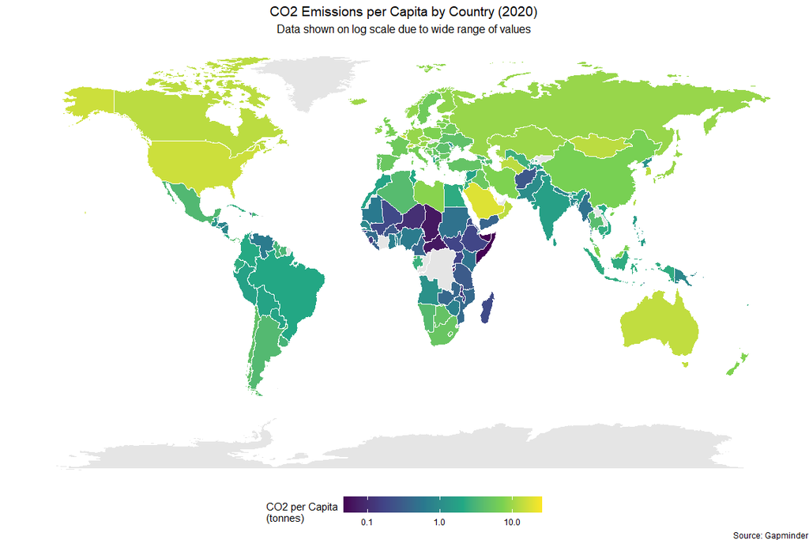

### GDP per Capita (2020)

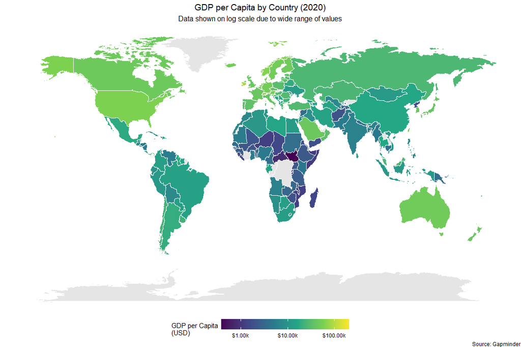

## Merged Data Analysis

| Country | CO2 per Capita (tonnes) | GDP per Capita (USD) |
| --- | --- | --- |
| Afghanistan | 0.261 | 1970 |
| Angola | 1.120 | 6030 |
| Albania | 2.000 | 13300 |
| Andorra | 5.630 | 49700 |
| UAE | 19.700 | 67400 |
| Argentina | 3.520 | 19600 |
| Armenia | 2.570 | 13300 |
| Antigua and Barbuda | 5.440 | 18500 |
| Australia | 13.700 | 48800 |
| Austria | 9.070 | 52100 |

Sample of Merged 2020 Data

| Indicator | Mean | Median | Min | Max |
| --- | --- | --- | --- | --- |
| CO2 per Capita | 4.52 | 2.57 | 0.02 | 25.6 |
| GDP per Capita | 19140.75 | 12400.00 | 387.00 | 110000.0 |

Summary Statistics for 2020 Data

## Relationship Analysis

### Scatterplot: CO2 vs GDP per Capita

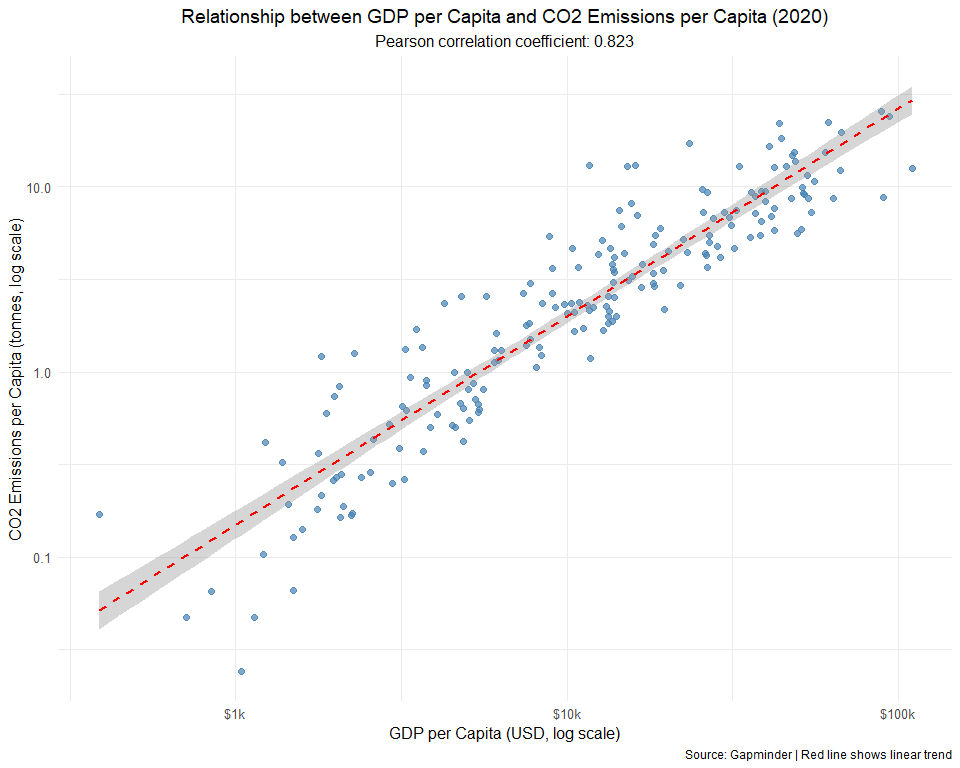

### Interpretation

The analysis reveals a **strong positive** relationship between GDP per capita and CO2 emissions per capita (r = 0.823).

**Key Findings:**

1. **Correlation Strength**: The Pearson correlation coefficient of 0.823 indicates a strong positive linear relationship between the two variables.
2. **Pattern Observed**: Countries with higher GDP per capita tend to have higher CO2 emissions per capita, suggesting that economic prosperity is associated with increased carbon emissions.
3. **Data Distribution**: Both variables show wide ranges across countries, with the logarithmic scales revealing that the relationship holds across different economic development levels.
4. **Policy Implications**: The strong positive correlation suggests that economic growth and environmental sustainability present a significant challenge, highlighting the importance of sustainable development strategies.

The relationship demonstrates the classic environmental Kuznets curve pattern in its early stages, where economic development initially leads to increased environmental degradation. However, some high-income countries are beginning to decouple economic growth from carbon emissions through cleaner technologies and structural economic changes.

### Reflection on the use of AI tools in this report

1. **AI Tools Used**: This report was developed using Cursor, an AI-powered coding assistant integrated into the development environment.
2. **Benefits Observed**: AI significantly accelerated code generation and allowed for seamless iteration and refinement of analysis scripts, boosting efficiency.
3. **Challenges Faced**: While AI expedited the coding process, maintaining accuracy and ensuring contextual relevance required careful validation and manual adjustments.
4. **Recommendations for Future Use of AI Tools**: AI tools can be powerful allies in data workflows, especially for prototyping and debugging, but should always be paired with domain expertise and critical review.